# Homework 4

Araks Karapetyan

27.10.2018

Read the file Cust_churn This dataset contains information about telecommunication company customers behavior The dataset includes information about: Customers who left within the last month - the column is called Churn The number of weeks since the subscription_variable name is Account Length The number of text messages (Message), number of minutes spent on day time, evening, night and for international calls in respective variables, The number of times a customer calls the call center (Callcenter enquiry) The variables Call.Plan and Message.Plan indicate whether the customer has subscription to call plan and/or message plan.

```r
churn <- read.csv("Cust_churn.csv")
churn
```

[output not shown]

[output cut: 6653 more lines]

The main objective of this assignment will be building models which will predict the customer churn (meaning that a customer stops using the services of this telecom company) as accurately as possible.

(1 point) Check if the classes of the variables are correctly understood by R, if not, change the types of the factor variables.

```r
str(churn)
```

```
## 'data.frame':    3333 obs. of  10 variables:
##  $ Churn             : int  0 0 0 0 0 0 0 0 0 0 ...
##  $ Account.Length    : int  128 107 137 84 75 118 121 147 117 141 ...
##  $ Messages          : int  25 26 0 0 0 0 24 0 0 37 ...
##  $ Day.Mins          : num  265 162 243 299 167 ...
##  $ Eve.Mins          : num  197.4 195.5 121.2 61.9 148.3 ...
##  $ Night.Mins        : num  245 254 163 197 187 ...
##  $ Intern..Min       : num  10 13.7 12.2 6.6 10.1 6.3 7.5 7.1 8.7 11.2 ...
##  $ CallCenter.enquiry: int  1 1 0 2 3 0 3 0 1 0 ...
##  $ Call.Plan         : int  0 0 0 1 1 1 0 1 0 1 ...
##  $ Message.Plan      : int  1 1 0 0 0 0 1 0 0 1 ...
```

```r
churn$Churn <- factor(churn$Churn, levels = c(0,1), labels = c("No", "Yes"))
churn$Call.Plan <- factor(churn$Call.Plan, levels = c(0,1), labels = c("No", "Yes"))
churn$Message.Plan <- factor(churn$Message.Plan, levels = c(0,1), labels = c("No", "Yes"))
```

(5 points) Run some exploratory analysis to explore the dependence between customer churn and other variables

```r
model <- glm(churn$Churn~.,churn,family = "binomial")
coef(model)
```

```
##        (Intercept)     Account.Length           Messages
##      -8.4577887614       0.0007724235       0.0346057688
##           Day.Mins           Eve.Mins         Night.Mins
##       0.0128741415       0.0071552360       0.0036794478
##        Intern..Min CallCenter.enquiry       Call.PlanYes
##       0.0846545503       0.5104340430       2.0172717952
##    Message.PlanYes
##      -1.9896900913
```

```r
exp(coef(model))
```

```
##        (Intercept)     Account.Length           Messages
##       0.0002122409       1.0007727219       1.0352115157
##           Day.Mins           Eve.Mins         Night.Mins
##       1.0129573700       1.0071808959       1.0036862252
##        Intern..Min CallCenter.enquiry       Call.PlanYes
##       1.0883410347       1.6660141598       7.5177868682
##    Message.PlanYes
##       0.1367377951
```

Visulize the relationship of call center enquiries and churn.

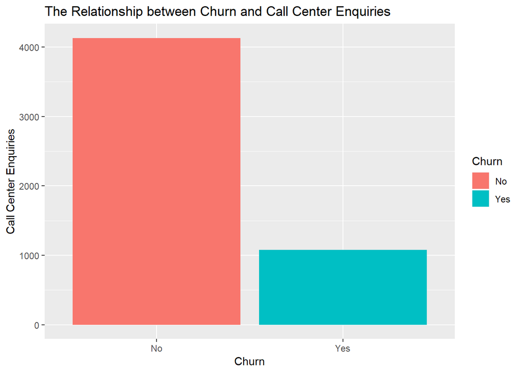

```r
library(ggplot2)
ggplot(churn, aes(x = Churn, y = CallCenter.enquiry, fill = Churn))+geom_bar(stat = "identity")+labs(x = "Churn", y = "Call Center Enquiries", title = "The Relationship between Churn and Call Center Enquiries")
```

Make visualization and comment on the difference between the distribution of minutes spent during daytime depending whether the customer left the company or not.

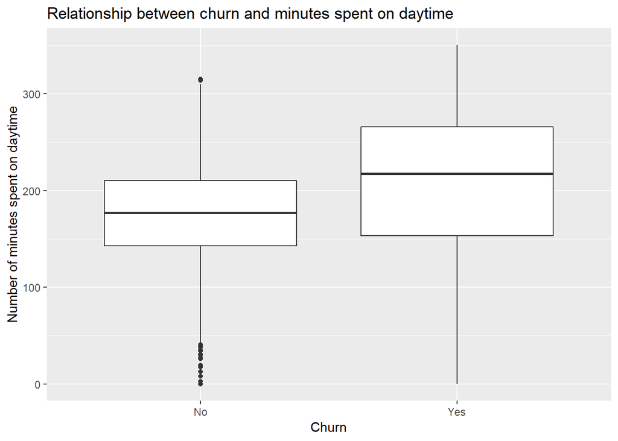

```r
ggplot(churn, aes(x = Churn, y = Day.Mins))+geom_boxplot()+labs(x = "Churn", y = "Number of minutes spent on daytime", title = "Relationship between churn and minutes spent on daytime")
```

```r
#As the median of Churn being yes is higher than Churn being No we can say that on average the customers who spent more hours during daytime are more likely to leave within the last month. Churn No has some outliers but the overall model is good.
```

Construct histograms for Evening minutes and night minutes depending on the churn and make your comments.

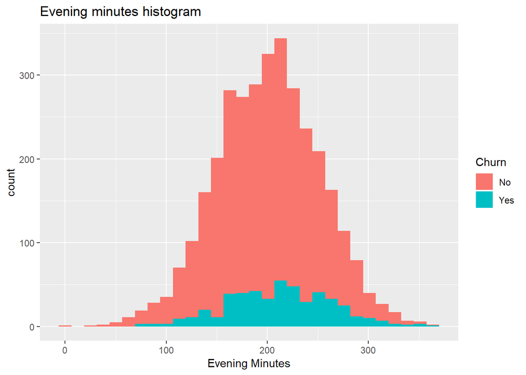

```r
ggplot(churn, aes(x = Eve.Mins, fill = Churn))+geom_histogram()+labs(x = "Evening Minutes", title = "Evening minutes histogram")
```

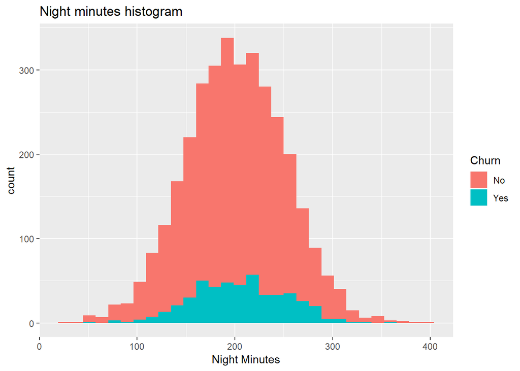

```r
#From the histogram we can say that the customers mainly talk between 100 to 300 Minutes during evening time, and only few customers talk between 150 to 250 mins during the evening time rejecting the services of the company.

ggplot(churn, aes(x = Night.Mins, fill = Churn))+geom_histogram()+labs(x = "Night Minutes", title = "Night minutes histogram")
```

```r
#From the histogram we can say that the customers mainly talk between 100 to 300 Minutes during night time, and only few customers talk between 100 to 300 mins during the night time rejecting the services of the company.
```

Create a variable total min which will be equal to the sum of minutes spent during day time, evening and night. Then visualize the distribution of this variable based on call plan and churn. comment on the finding.

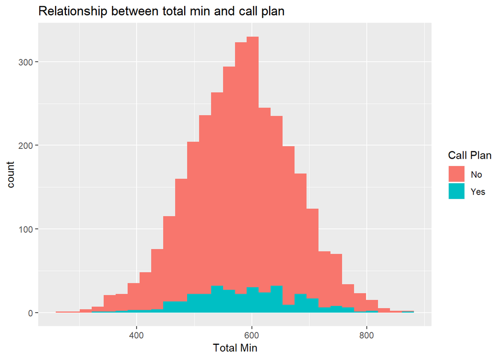

```r
churn$total.min <- churn$Day.Mins + churn$Eve.Mins + churn$Night.Mins
ggplot(churn, aes(x = total.min, fill = Call.Plan))+geom_histogram()+labs(x = "Total Min", fill = "Call Plan", title = "Relationship between total min and call plan")
```